# COMPSCX 415.2 Homework 9/Final Exam

Elizabeth Eldridge

March 30, 2019

## Exercise 1 - Sampling Distributions, Functions and For Loops (10 points)

# Step 1:

```r
samp_fun <- function(samp_size, samp_rate) {

  samp_size <- 100 #set the rate parameter
  samp_rate <- 1/10000 #take sample
  our_sample <- rexp(n = samp_size, rate = samp_rate) #take sample
  samp_avg <- our_sample %>% mean() #calculate mean of our sample
  samp_std_dev <- our_sample %>% sd() #calculate standard deviation of our sample
  stats <- list(samp_avg = samp_avg, samp_std_dev = samp_std_dev)
  return(stats)
}

samp_fun(stats)
```

```
## $samp_avg
## [1] 11178.23
##
## $samp_std_dev
## [1] 9796.687
```

# Step 2:

```r
n <- 1000
sample_means <- rep(NA, n) #empty vector for storing sample means
sample_sds <- rep(NA, n) #empty vector for storing sds

for (i in 1:n) {

  samp_size <- 50
  samp_rate <- 1/10000
  our_sample <- rexp(n = samp_size, rate = samp_rate)

  sample_means[i] <- mean(our_sample)
  sample_sds[i] <- sd(our_sample)
}

sample_means <- tibble(sample_means)
sample_means
```

```
## # A tibble: 1,000 x 1
##    sample_means
##           <dbl>
##  1        8531.
##  2       10209.
##  3       10506.
##  4        9775.
##  5       10996.
##  6       11496.
##  7        8500.
##  8       10002.
##  9        8326.
## 10        9009.
## # ... with 990 more rows
```

```r
sample_sds <- tibble(sample_sds)
sample_sds
```

```
## # A tibble: 1,000 x 1
##    sample_sds
##         <dbl>
##  1      8999.
##  2     12934.
##  3      9665.
##  4     11501.
##  5     11208.
##  6      8399.
##  7      7938.
##  8     10425.
##  9      8382.
## 10     10634.
## # ... with 990 more rows
```

# Step 3:

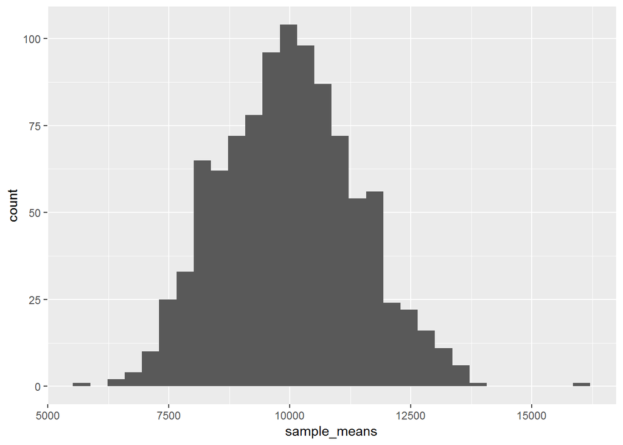

```r
#Plot sample means as a histogram
sample_means %>% ggplot(aes(x = sample_means)) +
geom_histogram()
```

```r
#output standard deviation of sample means
(sd(sample_means$sample_means))
```

```
## [1] 1401.733
```

```r
#calculate theoretical standard error
(sem <- 10000/(sqrt(samp_size)))
```

```
## [1] 1414.214
```

```r
#calculate the mean of the sample standard deviation
mean_sd <- (mean(sample_sds$sample_sds))
#and use this to calculate the empirical standard error
(ese <- mean_sd/(sqrt(samp_size)))
```

```
## [1] 1390.25
```

# Step 4:

```r
n <- 1000
sample_means <- rep(NA, n) #empty vector for storing sample means
sample_sds <- rep(NA, n) #empty vector for storing sds

for (i in 1:n) {

  samp_size <- 5000
  samp_rate <- 1/10000
  our_sample <- rexp(n = samp_size, rate = samp_rate)

  sample_means[i] <- mean(our_sample)
  sample_sds[i] <- sd(our_sample)
}

sample_means <- tibble(sample_means)
sample_means
```

```
## # A tibble: 1,000 x 1
##    sample_means
##           <dbl>
##  1       10246.
##  2        9862.
##  3       10095.
##  4        9946.
##  5       10127.
##  6        9809.
##  7       10164.
##  8       10046.
##  9        9883.
## 10        9939.
## # ... with 990 more rows
```

```r
sample_sds <- tibble(sample_sds)
sample_sds
```

```
## # A tibble: 1,000 x 1
##    sample_sds
##         <dbl>
##  1     10228.
##  2      9671.
##  3     10344.
##  4      9808.
##  5     10144.
##  6     10075.
##  7     10169.
##  8      9828.
##  9      9994.
## 10      9967.
## # ... with 990 more rows
```

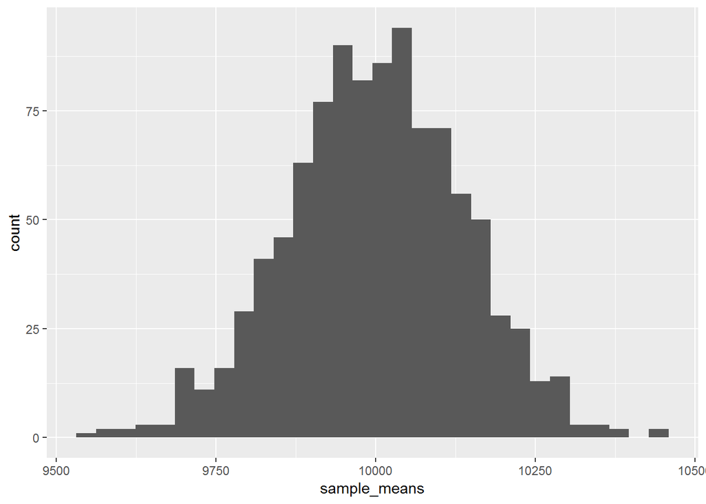

```r
#Plot sample means as a histogram
sample_means %>% ggplot(aes(x = sample_means)) +
geom_histogram()
```

```r
#output standard deviation of sample means
(sd(sample_means$sample_means))
```

```
## [1] 137.6366
```

```r
#calculate theoretical standard error
sem <- 10000/(sqrt(samp_size))
sem
```

```
## [1] 141.4214
```

```r
#calculate the mean of the sample standard deviation
mean_sd <- (mean(sample_sds$sample_sds))
#and use this to calculate the empirical standard error
ese <- mean_sd/(sqrt(samp_size))
ese
```

```
## [1] 141.3679
```

## Exercise 2 - Linear Regression (5 points)

```r
#Load train data
traindata <- read_csv('I:/train.csv')
#Fit a regression model with y = SalePrice and Features: LotArea, OverallQual, ExterQual
lin_mod1 <- lm(formula = SalePrice ~ LotArea + OverallQual + ExterQual, data = traindata)

#Use the broom package to output the coefficients and the R-squared
tidy(lin_mod1)
```

```
## # A tibble: 6 x 5
##   term         estimate std.error statistic   p.value
##   <chr>           <dbl>     <dbl>     <dbl>     <dbl>
## 1 (Intercept)  40764.   12358.         3.30 9.95e-  4
## 2 LotArea          1.45     0.116     12.5  3.72e- 34
## 3 OverallQual  34466.    1216.        28.3  4.77e-141
## 4 ExterQualFa -95352.   14592.        -6.53 8.80e- 11
## 5 ExterQualGd -71529.    6737.       -10.6  2.05e- 25
## 6 ExterQualTA -97527.    7541.       -12.9  2.72e- 36
```

```r
glance(lin_mod1)
```

```
## # A tibble: 1 x 11
##   r.squared adj.r.squared  sigma statistic p.value    df  logLik    AIC
##       <dbl>         <dbl>  <dbl>     <dbl>   <dbl> <int>   <dbl>  <dbl>
## 1     0.695         0.694 43948.      663.       0     6 -17677. 35368.
## # ... with 3 more variables: BIC <dbl>, deviance <dbl>, df.residual <int>
```

```r
#Check to confirm that 'Poor' is never assigned as a value for ExterQual in this dataset, reference level in model is 'Excellent'
unique(traindata$ExterQual)
```

```
## [1] "Gd" "TA" "Ex" "Fa"
```

*Answer these questions:*  
**Use the broom package to output the coefficients and the R-squared**  
- See above code block.

**Interpret the coefficient on LotArea**  
- For every square foot of Lot size, the sale price increases, on average, by $1.45, with all other features being held constant.

**Interpret the coefficient on ExterQualGd**  
- The mean difference in the sale price between a property with ‘Excellent’ quality of the material on the exterior and a property with ‘Good’ quality of the material on the exterior is -$71,529.49, so ‘Good’ quality houses are less expensive than those with ‘Excellent’ quality material.

**Compare this model to the model we fit in HW 7 with GrLivArea, OverallQual, Neighborhood. Which is the better fitting model?**  
- The adjusted R-squared for the model fit in Hw 7 was 0.78 and the adjusted R-squared for this model is 0.69, so the model we fit in Hw 7 was a better fitting model.

## Exercise 3 - AB Testing (5 points)

```r
#Load A/B Test data
ab_dat <- read_csv('I:/ab_test_data.csv')
#Proportion of visitors converted for each verion of the webpage
ab_dat %>%
  group_by(version, conversion) %>%
  summarise(n = n()) %>%
  mutate(freq = n / sum(n))
```

```
## # A tibble: 4 x 4
## # Groups:   version [2]
##   version conversion     n   freq
##   <chr>        <dbl> <int>  <dbl>
## 1 A                0  1917 0.958
## 2 A                1    83 0.0415
## 3 B                0  1800 0.9
## 4 B                1   200 0.1
```

```r
#A/B Test in R
true_a <- .0415
true_b <- .1000
n_a <- 2000
n_b <- 2000

set.seed(10)
samp_a <- rbinom(n = 1, size = n_a, prob = true_a)
samp_b <- rbinom(n = 1, size = n_b, prob = true_b)

samp_a
```

```
## [1] 93
```

```r
samp_b
```

```
## [1] 200
```

```r
two_prop_test <- prop.test(c(samp_a, samp_b), c(2000, 2000))
two_prop_test$p.value
```

```
## [1] 1.25388e-10
```

*Answer these questions:*  
**What proportion of visitors converted for each version of the webpage?**  
- 4.2% of Version A visitors converted and 10% of Version B visitors converted.

**Perform the AB test in R. What is the p-value for the AB test (hypothesis test of proportions)?**  
- The p-value for the AB test is 1.25388e-10. The p-value is the probability of observing a statistic as extreme, or more extreme, than what we got, if the null is true. If p-value < 0.05, we reject the null hypothesis. Therefore, we can reject the null hypothesis in this case.